# dataviz hypothesis

2026-08-19

```r
# rename the four columns we use, once, so everything below reads plainly
climate <- read.csv("data/climate_change.csv") %>%
  rename(country   = Pacific.Island.Countries.and.territories,
         year      = TIME_PERIOD,
         value     = OBS_VALUE,
         indicator = CLIMATE_CHANGE_INDICATORS)

roni <- read.csv("data/roni.csv") %>% select(year = Year, roni = MEAN)

sea_temp <- filter(climate, indicator == "SST_ANOM")   # degrees C, 1850-2025
rain     <- filter(climate, indicator == "RAIN_ANOM")  # mm, 1979-2025
sea_lvl  <- filter(climate, indicator == "SEA_LVL")    # metres, 1993-2023
stations <- filter(climate, indicator == "METEO_MONITOR_NET")

# one row per country-year, always. this is the check that catches the old bug
stopifnot(nrow(count(sea_temp, country, year) %>% filter(n > 1)) == 0)
```

```r
# GHCN-D and IGRA key on FIPS-2 (first two characters of the station ID);
# WDQMS uses ISO3. Everything joins through this table.
xwalk <- tribble(
  ~fips, ~iso3,  ~country,                    ~grp,
  "PP",  "PNG",  "Papua New Guinea",          "PICT",
  "BP",  "SLB",  "Solomon Islands",           "PICT",
  "NH",  "VUT",  "Vanuatu",                   "PICT",
  "NC",  "NCL",  "New Caledonia",             "PICT",
  "FJ",  "FJI",  "Fiji",                      "PICT",
  "TN",  "TON",  "Tonga",                     "PICT",
  "WS",  "WSM",  "Samoa",                     "PICT",
  "AQ",  "ASM",  "American Samoa",            "PICT",
  "NE",  "NIU",  "Niue",                      "PICT",
  "CW",  "COK",  "Cook Islands",              "PICT",
  "TV",  "TUV",  "Tuvalu",                    "PICT",
  "KR",  "KIR",  "Kiribati",                  "PICT",
  "NR",  "NRU",  "Nauru",                     "PICT",
  "TL",  "TKL",  "Tokelau",                   "PICT",
  "RM",  "MHL",  "Marshall Islands",          "PICT",
  "FM",  "FSM",  "Micronesia",                "PICT",
  "PS",  "PLW",  "Palau",                     "PICT",
  "GQ",  "GUM",  "Guam",                      "PICT",
  "CQ",  "MNP",  "Northern Mariana Islands",  "PICT",
  "FP",  "PYF",  "French Polynesia",          "PICT",
  "WF",  "WLF",  "Wallis and Futuna",         "PICT",
  "PC",  "PCN",  "Pitcairn",                  "PICT",
  "AS",  "AUS",  "Australia",                 "Comparator",
  "NZ",  "NZL",  "New Zealand",               "Comparator"
)

pict       <- filter(xwalk, grp == "PICT")$country
ACTIVE_CUT <- 2021
```

```r
igra <- read_fwf(
  "data/igra2-station-list.txt",
  fwf_positions(c(1, 13, 22, 32, 42, 73, 78, 83),
                c(11, 20, 30, 37, 71, 76, 81, 88),
                c("id", "lat", "lon", "elev", "name", "first", "last", "nobs")),
  col_types = "cddd" %>% paste0("ciii")
) %>%
  mutate(fips = str_sub(id, 1, 2)) %>%
  inner_join(xwalk, by = "fips")

ghcn_stn <- read_fwf(
  "data/ghcnd-stations.txt",
  fwf_positions(c(1, 13, 22, 32, 42), c(11, 20, 30, 37, 71),
                c("id", "lat", "lon", "elev", "name")),
  col_types = "cdddc"
)

ghcn_prcp <- read_fwf(
  "data/ghcnd-inventory.txt",
  fwf_positions(c(1, 13, 22, 32, 37, 42), c(11, 20, 30, 35, 40, 45),
                c("id", "lat", "lon", "elem", "first", "last")),
  col_types = "cddcii"
) %>%
  filter(elem == "PRCP") %>%
  mutate(fips = str_sub(id, 1, 2)) %>%
  inner_join(xwalk, by = "fips") %>%
  left_join(select(ghcn_stn, id, elev, name), by = "id")

stopifnot(nrow(igra) > 0, nrow(ghcn_prcp) > 0)
```

```r
# ---------------------------------------------------------------------
# WDQMS status categories:
#   green   normal / complete
#   purple  more than declared in OSCAR - schedule metadata fault, but
#           the data IS arriving, so counted as reporting
#   orange  availability issue, >= 30% received
#   red     availability issue, < 30% received
#   black   nothing received in the period
#   grey    OSCAR schedule issue      } metadata faults,
#   yellow  no match in OSCAR/Surface }  excluded from every rate
#
# Each station appears once per monitoring centre (DWD, ECMWF, JMA,
# NCEP). WDQMS shows the best result across centres; collapse the same way.
# ---------------------------------------------------------------------
status_rank <- c(green = 1, purple = 2, orange = 3, red = 4,
                 grey = 5, yellow = 6, black = 7)

# Pacific territories report under the administering country's ISO code.
# Guam and American Samoa appear as USA; without this they vanish from
# the per-country tables and appear to have no stations at all.
reassign_territory <- function(df) {
  mutate(df, iso3 = case_when(
    str_detect(name, regex("GUAM", ignore_case = TRUE))                     ~ "GUM",
    str_detect(name, regex("PAGO PAGO|AMERICAN SAMOA", ignore_case = TRUE)) ~ "ASM",
    str_detect(name, regex("SAIPAN|TINIAN|ROTA", ignore_case = TRUE))       ~ "MNP",
    str_detect(name, regex("WALLIS|FUTUNA|HIHIFO", ignore_case = TRUE))     ~ "WLF",
    TRUE ~ iso3))
}

read_wdqms <- function(path) {
  read_csv(path, show_col_types = FALSE) %>%
    rename(status = `color code`, iso3 = `country code`,
           received = `#received`, expected = `#expected`) %>%
    reassign_territory() %>%
    mutate(rank = status_rank[status]) %>%
    arrange(rank) %>%
    distinct(wigosid, iso3, .keep_all = TRUE) %>%
    inner_join(xwalk, by = "iso3")
}

land  <- read_wdqms("data/wdqms_LandSurface_synop_availability_monthly_pressure_oscar_2026-07.csv")
upper <- read_wdqms("data/wdqms_UpperAir_temp_availability_monthly_oscar_2026-07.csv")

# the marine quality export reports `rms` - root-mean-square departure
# of the observation from the model background, in hPa
marine <- read_csv("data/wdqms_marine_surface_quality_monthly_pressure_2026-07.csv",
                   show_col_types = FALSE) %>%
  rename(departure = rms)

reporting_rate <- function(df, layer) {
  df %>%
    filter(!status %in% c("grey", "yellow")) %>%
    group_by(country, grp) %>%
    summarise(registered = n(),
              reporting  = sum(status %in% c("green", "purple")),
              silent     = sum(status == "black"),
              received   = sum(received),
              expected   = sum(expected), .groups = "drop") %>%
    mutate(pct_obs = if_else(expected > 0, round(100 * received / expected), NA_real_),
           layer   = layer)
}
```

# 1. Start with you

*“When and where were you born?”*

```r
birth_year <- 1990
place      <- "Nauru"

mine <- filter(sea_temp, country == place)
then <- mean(mine$value[mine$year >= birth_year & mine$year < birth_year + 10])
now  <- mean(mine$value[mine$year >= 2016])

round(now - then, 1)
```

```
## [1] 0.4
```

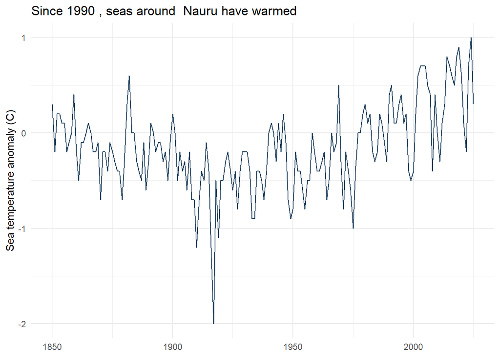

```r
ggplot(mine, aes(year, value)) +
  geom_line(colour = "#1a3d5c") +
  labs(title = paste("Since", birth_year, ", seas around ", place, "have warmed"),
       x = NULL, y = "Sea temperature anomaly (C)") +
  theme_minimal()
```

# 2. The long record was never about these islands

Ships logged sea temperature on their way to somewhere else, and satellites read the surface from orbit. Both cover the Pacific incidentally. Neither was set up to watch these islands.

That matters for everything below. A line drawn back to 1850 is not the same thing as a country measuring its own weather, and the two come apart badly once we look at what is on the ground.

```r
# average the countries so the shared signal shows through
yearly <- sea_temp %>% group_by(year) %>% summarise(temp = mean(value))

# a "hinge" is 0 before its year and counts years after it,
# so adding two of them lets the slope change twice
hinge <- function(x, b) pmax(0, x - b)

fit <- lm(temp ~ year + hinge(year, 1915) + hinge(year, 1985), yearly)

# the coefficients are changes in slope, so add them up as you go
round(cumsum(coef(fit)[-1]) * 10, 2)      # degrees C per decade, per era
```

```
##              year hinge(year, 1915) hinge(year, 1985)
##             -0.06              0.06              0.17
```

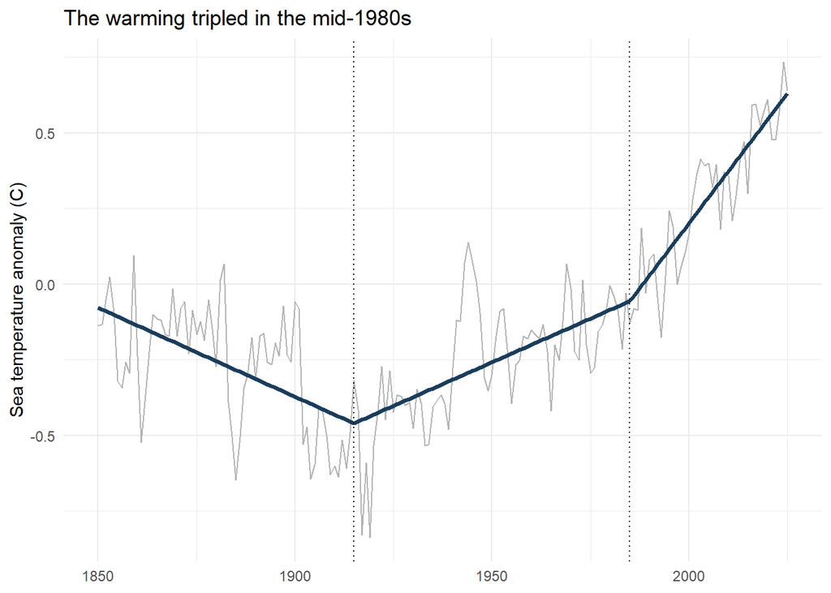

```r
yearly$fitted <- predict(fit)

ggplot(yearly, aes(year)) +
  geom_line(aes(y = temp), colour = "grey70") +
  geom_line(aes(y = fitted), colour = "#1a3d5c", linewidth = 1.2) +
  geom_vline(xintercept = c(1915, 1985), linetype = "dotted") +
  labs(title = "The warming tripled in the mid-1980s",
       x = NULL, y = "Sea temperature anomaly (C)") +
  theme_minimal()
```

Sea temperatures are rising alongside sea levels, and every country is affected.

```r
warming <- sea_temp %>% filter(year >= 1985) %>% group_by(country) %>%
  summarise(per_decade = coef(lm(value ~ year))[2] * 10)

rising <- sea_lvl %>% group_by(country) %>%
  summarise(mm_per_year = coef(lm(value ~ year))[2] * 1000)

# Deliberately not a chart. The finding is "all of them", and four numbers say
# that more plainly than 22 near-identical upward lines would. Drop the chunk
# entirely if the sentence above carries it.
c(countries_warming = sum(warming$per_decade > 0), of = nrow(warming),
  countries_rising  = sum(rising$mm_per_year > 0), of = nrow(rising))
```

```
## countries_warming                of  countries_rising                of
##                21                21                21                21
```

# 3. Rainfall is the signal that hurts, and it swings

Temperature is the thing the long record measures well. Rainfall is the thing people plan around, and it behaves differently. It does not climb. It lurches: a year of too much, then a year of nothing.

```r
window   <- c(1985, max(rain$year))
rain_win <- filter(rain, year >= window[1])

jump  <- rain_win %>% group_by(country) %>% summarise(s = sd(value))
climb <- rain_win %>% group_by(country) %>%
  summarise(t = coef(lm(value ~ year))[2] * 10)   # mm per decade

# median ABSOLUTE trend - the signed median lets wetting and drying countries
# cancel, which is what inflated this to 8.5
trend <- median(abs(climb$t))
ratio <- median(jump$s) / trend

round(median(jump$s), 1)   # 11.9
```

```
## [1] 11.9
```

```r
round(trend, 1)            # 2.5
```

```
## [1] 2.5
```

```r
round(ratio, 1)            # 4.7
```

```
## [1] 4.8
```

From one year to the next, rainfall moves about 5 times as far as its trend moves in a decade (1985–2025). Year-to-year movement here is the median country standard deviation (11.9 mm); trend is the median absolute per-decade trend (2.5 mm).

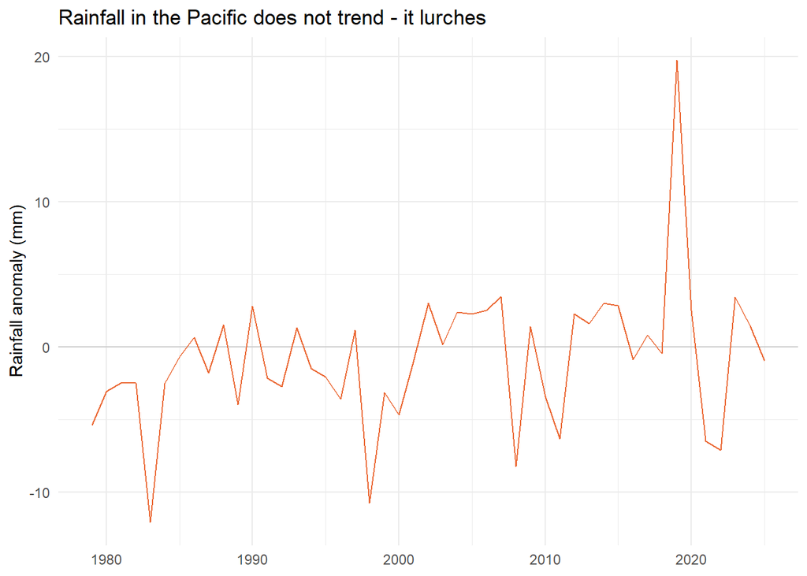

```r
ggplot(rain |> group_by(year) |> summarise(value=mean(value)),
              aes(year, value)) +
  geom_hline(yintercept = 0, colour = "grey80") +
  geom_line(colour = "#eb6834") +
  labs(title = paste("Rainfall in the Pacific does not trend - it lurches"),
       x = NULL, y = "Rainfall anomaly (mm)") +
  theme_minimal()
```

The temperature trend was only measurable because the same places were measured the same way for decades. Rainfall asks for more than that. It moves faster and over shorter distances, so seeing it takes more instruments in more places — and it is the thing the region has fewest instruments for.

The swings are not random, which is what makes them forecastable in principle. During El Niño, warm water slides east and the rain follows it, so one half of the Pacific is wet while the other is dry.

```r
# Assignment by geography, fixed before looking at the rainfall series, so the
# El Nino effect is tested against an external map rather than derived from the
# same index that defines it.
#
# MECHANISM: Brown, Lengaigne, Lintner, Widlansky, van der Wiel, Dutheil,
# Linsley, Matthews & Renwick (2020), "South Pacific Convergence Zone dynamics,
# variability and impacts in a changing climate", Nature Reviews Earth &
# Environment. Islands near the equator and east of the mean SPCZ get wetter;
# islands south-west of it get drier.
#
# PER-COUNTRY: BoM/CSIRO PACCSAP country brochures, pacificclimatechangescience.org,
# except New Caledonia (Meteo-France) and Tokelau (NIWA Island Climate Update).
# Every quote below was checked against its source document. Note how many are
# station-specific - Suva, Nuku'alofa, Funafuti, Port Vila - which is the
# station argument turning up inside this section's own sourcing.
spcz_itcz <- c(
  # south-west Pacific - the SPCZ moves away from them
  'Papua New Guinea' = 'dry',   # "El Nino years are usually drier than normal"
  'Solomon Islands'  = 'dry',   # "warmer, drier wet season conditions"
  'New Caledonia'    = 'dry',   # Meteo-France: "un risque accru de secheresse"
  'Vanuatu'          = 'dry',   # Port Vila, Aneityum: "tend to bring drier conditions"
  'Fiji'             = 'dry',   # Suva: dry seasons "drier and cooler than normal"
  'Tonga'            = 'dry',   # Nuku'alofa, Lupepau'u: "drier wet seasons than normal"
  'Samoa'            = 'dry',   # "wet seasons that are drier than normal"
  'Niue'             = 'dry',   # "drier than normal, particularly in the wet season"
  # equatorial central Pacific - the convection moves over them
  'Kiribati'         = 'wet',   # "Across Kiribati... wetter, warmer conditions than normal"
  'Tuvalu'           = 'wet',   # Funafuti: "wetter, warmer conditions than normal"
  'Nauru'            = 'wet',   # "warmer, wetter conditions than normal"
  'Tokelau'          = 'wet'    # NIWA ICU 111 (Dec 2009): "enhanced convection... near Tokelau"
)
# Two corrections made on checking the sources:
#   - the earlier Tuvalu quote ("the SPCZ tends to move to the north-east over
#     Tuvalu") is NOT in the brochure. Direction is right; quote replaced with
#     the Funafuti sentence, which is.
#   - the Kiribati brochure says "Across Kiribati" and does not split Gilberts
#     from Line Islands. That distinction is Brown et al., not the brochure.

wet_side <- names(spcz_itcz)[spcz_itcz == "wet"]
dry_side <- names(spcz_itcz)[spcz_itcz == "dry"]
# Ten countries left out, each for a reason - they have no single El Nino
# rainfall direction, so averaging them in would blur the split rather than
# test it.
#   Palau, Micronesia, Marshall Islands, Guam, N. Mariana Islands
#     Micronesia runs on a lag: near or above normal early in the El Nino year,
#     drought Jan-Mar of the FOLLOWING year. An annual mean cancels the two.
#   Cook Islands       Rarotonga drier, northern atolls wetter.
#   French Polynesia   Marquesas wetter, Australes drier, sign flips with flavour.
#   Wallis and Futuna  Meteo-France: ENSO has little significant effect there.
#   American Samoa     Sits on the SPCZ axis; individual events go both ways.
#   Pitcairn           No authoritative ENSO rainfall assessment exists.
excluded <- setdiff(unique(rain$country), names(spcz_itcz))
excluded
```

```
##  [1] "Marshall Islands"               "Wallis and Futuna"
##  [3] "Northern Mariana Islands"       "Pitcairn"
##  [5] "Guam"                           "French Polynesia"
##  [7] "Micronesia, Federated State of" "Palau"
##  [9] "American Samoa"                 "Cook Islands"
```

```r
lean <- rain %>% inner_join(roni, by = "year") %>% group_by(country) %>%
  summarise(r = cor(value, roni))

check <- lean %>% filter(country %in% names(spcz_itcz)) %>%
  mutate(assigned = spcz_itcz[country],
         agrees   = (assigned == "wet" & r > 0) | (assigned == "dry" & r < 0))

check
```

```
## # A tibble: 12 × 4
##    country                r assigned agrees
##    <chr>              <dbl> <chr>    <lgl>
##  1 Fiji             -0.478  dry      TRUE
##  2 Kiribati          0.865  wet      TRUE
##  3 Nauru             0.852  wet      TRUE
##  4 New Caledonia    -0.439  dry      TRUE
##  5 Niue             -0.561  dry      TRUE
##  6 Papua New Guinea -0.666  dry      TRUE
##  7 Samoa            -0.0661 dry      TRUE
##  8 Solomon Islands  -0.210  dry      TRUE
##  9 Tokelau           0.530  wet      TRUE
## 10 Tonga            -0.436  dry      TRUE
## 11 Tuvalu            0.680  wet      TRUE
## 12 Vanuatu          -0.727  dry      TRUE
```

```r
mean(check$agrees)   # proportion of data agrees with the map
```

```
## [1] 1
```

```r
wet <- rain %>% filter(country %in% wet_side) %>% group_by(year) %>%
  summarise(m = mean(value))   # mean rainfall anomaly, wet-side countries
dry <- rain %>% filter(country %in% dry_side) %>% group_by(year) %>%
  summarise(m = mean(value))   # mean rainfall anomaly, dry-side countries

# Check before writing prose around the chart. Brown et al. note that in the
# strongest eastern-Pacific events - 1982-83 and 1997-98 - Nauru and Tarawa
# went DRY despite normally being wetter, because the convection overshoots
# the Gilberts and sits over the Line Islands.
rain %>% filter(country %in% wet_side, year %in% c(2015, 2016)) %>%
  select(country, year, value) %>% arrange(country, year)
```

```
##    country year value
## 1 Kiribati 2015  50.3
## 2 Kiribati 2016  13.0
## 3    Nauru 2015  49.5
## 4    Nauru 2016  -5.0
## 5  Tokelau 2015  22.4
## 6  Tokelau 2016  10.0
## 7   Tuvalu 2015  29.4
## 8   Tuvalu 2016   5.9
```

```r
split <- inner_join(wet, dry, by = "year", suffix = c("_wet", "_dry")) %>%
  mutate(gap = m_wet - m_dry)

filter(split, year %in% c(2015, 2016))   # the event this piece follows
```

```
## # A tibble: 2 × 4
##    year m_wet m_dry   gap
##   <int> <dbl> <dbl> <dbl>
## 1  2015 37.9  -9.36  47.3
## 2  2016  5.98 -4.04  10.0
```

```r
round(median(abs(split$gap)), 1)         # a normal year, for scale
```

```
## [1] 16.1
```

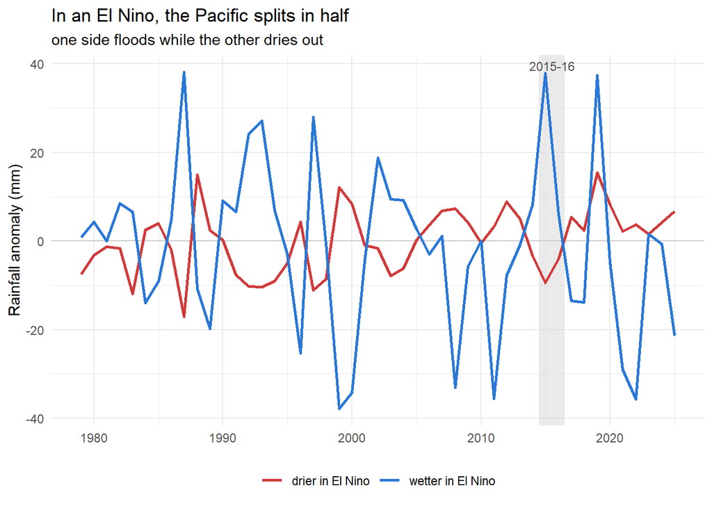

```r
# Only 2015-16 is shaded. An earlier version also shaded 1999-2000 and labelled
# it an El Nino - that was a strong La Nina, so it has been removed rather than
# corrected, since the piece follows one event.
sides <- bind_rows(mutate(wet, side = "wetter in El Nino"),
                   mutate(dry, side = "drier in El Nino"))

ggplot(sides, aes(year, m, colour = side)) +
  annotate("rect", xmin = 2014.5, xmax = 2016.5,
           ymin = -Inf, ymax = Inf, fill = "grey85", alpha = .55) +
  annotate("text", x = 2015.5, y = Inf, label = "2015-16",
           vjust = 1.6, size = 3, colour = "grey30") +
  geom_hline(yintercept = 0, colour = "grey80") +
  geom_line(linewidth = 1) +
  scale_colour_manual(values = c("wetter in El Nino" = "#2a78d6",
                                 "drier in El Nino"  = "#d03b3b")) +
  labs(title = "In an El Nino, the Pacific splits in half",
       subtitle = "one side floods while the other dries out",
       x = NULL, y = "Rainfall anomaly (mm)", colour = NULL) +
  theme_minimal() + theme(legend.position = "bottom")
```

So the mechanism is known and the pattern holds. But a farmer does not plant against a pattern for half an ocean. What has to be forecast is how much rain falls in one district, and when it stops — and that is a question you can only answer from the record of that district.

# 4. What that cost: Papua New Guinea, 2015

In Papua New Guinea the rain began falling away in April 2015. Between mid-July and mid-August, at the one high-altitude research station recording it, temperatures fell to minus two degrees before dawn. The frosts destroyed sweet potato, the staple, in gardens above 2,200 metres — where a replanted crop takes eight to twelve months to mature.[^1]

By the time anyone tried to count, food was very scarce or extremely scarce in 27 of Papua New Guinea’s 271 rural districts. Those districts hold about 770,000 people, though the assessment calls that an upper limit and says the number actually short of food is likely to be considerably less, since not everyone in a district was equally affected. Nearly nine in ten of them live in the highlands.[^2]

That assessment was built from more than two hundred reports — formal surveys, emails, phone calls, newspaper stories, photographs posted on Facebook. It covered 141 of the 271 districts. The other 130 were estimated from what had happened nearby, and from what had happened in 1997. It remains the only national account of the emergency at that resolution. Its authors asked for the numbers to be checked in the field. That was not done.[^3]

There is no official death toll. Australia’s review of its own response says an increase in mortality is likely and impossible to quantify.[^4]

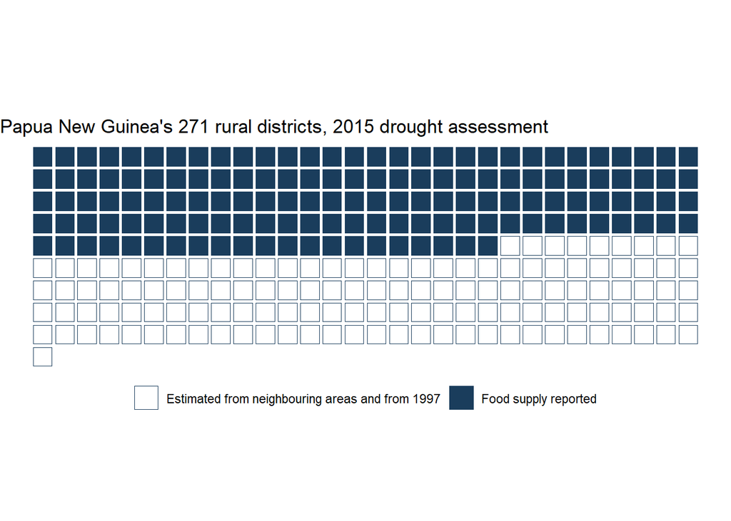

```r
# Coverage. The brief obtained food supply information for 141 of the 271
# rural districts and extrapolated the other 130 from neighbouring areas and
# from what happened in 1997. This is the chart the section rests on.
coverage <- data.frame(i = 0:270) %>%
  mutate(row = i %/% 30, col = i %% 30,
         status = ifelse(i < 141, "Food supply reported",
                                  "Estimated from neighbouring areas and from 1997"))

ggplot(coverage, aes(col, -row, fill = status)) +
  geom_tile(colour = "#1a3d5c", linewidth = .35, width = .85, height = .85) +
  scale_fill_manual(values = c("Food supply reported" = "#1a3d5c",
    "Estimated from neighbouring areas and from 1997" = "white")) +
  coord_equal() +
  labs(title = "Papua New Guinea's 271 rural districts, 2015 drought assessment",
       fill = NULL) +
  theme_void() + theme(legend.position = "bottom")
```

```r
# Table 2 of Policy Brief 11, transcribed by hand from the PDF.
# CHECK IT: these columns sum to 752,234 against the brief's published
# subtotal of 752,227, so at least one figure is misread.
llg <- read.csv("data/png_2015_cat45_llga.csv")
```

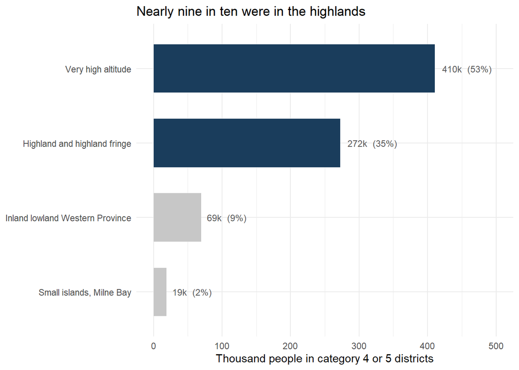

```r
# Where the affected population was. Milne Bay is hard-coded because it is
# Table 3 of the brief, which is not in the csv - add those seven island
# wards if this chart is used.
zones <- llg %>% group_by(zone) %>% summarise(pop = sum(pop_2015_est)) %>%
  bind_rows(data.frame(zone = "Small islands, Milne Bay", pop = 18705)) %>%
  mutate(share = pop / sum(pop),
         highlands = zone %in% c("Very high altitude", "Highland and highland fringe"))

ggplot(zones, aes(pop / 1000, reorder(zone, pop), fill = highlands)) +
  geom_col(width = .65) +
  geom_text(aes(label = sprintf("%.0fk  (%.0f%%)", pop / 1000, share * 100)),
            hjust = -.15, size = 3.1, colour = "grey35") +
  scale_fill_manual(values = c("TRUE" = "#1a3d5c", "FALSE" = "grey78"), guide = "none") +
  expand_limits(x = 500) +
  labs(title = "Nearly nine in ten were in the highlands",
       x = "Thousand people in category 4 or 5 districts", y = NULL) +
  theme_minimal()
```

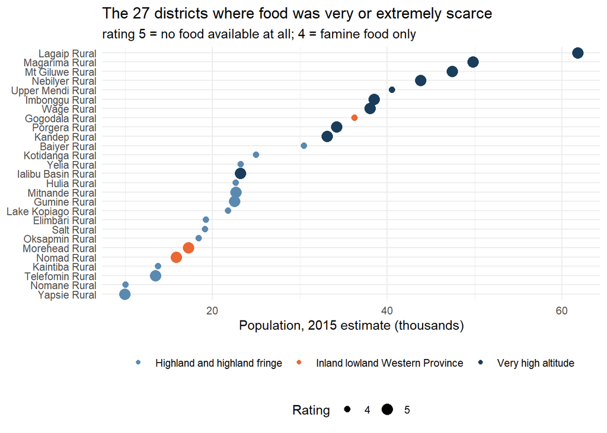

```r
# The 27 districts themselves.
ggplot(llg, aes(pop_2015_est / 1000, reorder(llga, pop_2015_est),
                colour = zone, size = factor(rating))) +
  geom_point() +
  scale_size_manual(values = c("4" = 2.2, "5" = 4), name = "Rating") +
  scale_colour_manual(values = c("Very high altitude" = "#1a3d5c",
                                 "Highland and highland fringe" = "#5b8ab0",
                                 "Inland lowland Western Province" = "#eb6834"),
                      name = NULL) +
  labs(title = "The 27 districts where food was very or extremely scarce",
       subtitle = "rating 5 = no food available at all; 4 = famine food only",
       x = "Population, 2015 estimate (thousands)", y = NULL) +
  theme_minimal() + theme(legend.position = "bottom", legend.box = "vertical")
```

The ocean was watched. By early April 2015, forecasters including the Australian Bureau of Meteorology were reporting a severe El Niño moving west.[^5] What no one could say was how much rain would fall in the Kandep basin, or when it would stop.

An El Niño declaration is a statement about the ocean. A rainfall forecast for a district is a different thing: it is built from what rainfall at that place has done in past El Niños, so it can only ever be as local as the record behind it. The highlands are where most of Papua New Guinea’s people live, between roughly 1,500 and 2,800 metres. They are also where almost none of the measurement is.

# 5. Rainfall takes three layers

Rainfall is not one measurement. It takes three, and they do different jobs.

- **The ocean surface** — buoys and ships — shows where the warm water and the moisture sit, weeks to seasons ahead.
- **The upper air** — radiosondes on balloons — shows where the convection will go over the next few days.
- **The ground** — rain gauges — records what actually arrived, and calibrates everything else, including the satellites.

In the Pacific, one of these works, one is thin and misplaced, and one has effectively gone.

## The ocean layer works

```r
pacific_box <- marine %>%
  filter(between(latitude, -30, 25), longitude >= 130 | longitude <= -130)

tibble(platforms_pacific   = nrow(pacific_box),
       platforms_global    = nrow(marine),
       median_rms_pacific  = round(median(pacific_box$departure), 2),
       median_rms_global   = round(median(marine$departure), 2),
       pct_within_1hPa_pac = round(100 * mean(pacific_box$departure <= 1)),
       pct_within_1hPa_glb = round(100 * mean(marine$departure <= 1)))
```

```
## # A tibble: 1 × 6
##   platforms_pacific platforms_global median_rms_pacific median_rms_global
##               <int>            <int>              <dbl>             <dbl>
## 1               260             4178                0.3              0.38
## # ℹ 2 more variables: pct_within_1hPa_pac <dbl>, pct_within_1hPa_glb <dbl>
```

```r
count(pacific_box, marine_type)
```

```
## # A tibble: 2 × 2
##   marine_type     n
##   <chr>       <int>
## 1 buoy          172
## 2 ship           88
```

260 platforms reported in the tropical Pacific through July 2026 — moorings along the equator, ships on the lanes, drifters between. 85% sat within 1 hPa RMS of the forecast model, against 78% globally. The ocean around these islands is better observed than the ocean on average.

Almost none of it is paid for or operated from within the region, which matters for how long it lasts. It does not matter for whether the data exists today. It exists.

## The ground layer is at sea level, and half of it is silent

```r
png_gauges <- filter(ghcn_prcp, country == "Papua New Guinea")

png_summary <- png_gauges %>%
  summarise(ever         = n(),
            active       = sum(last >= ACTIVE_CUT),
            highest_ever = max(elev, na.rm = TRUE),
            above_1000   = sum(elev > 1000, na.rm = TRUE))

png_summary
```

```
## # A tibble: 1 × 4
##    ever active highest_ever above_1000
##   <int>  <int>        <dbl>      <int>
## 1    15      5         72.8          0
```

Of Papua New Guinea’s 15 internationally exchanged rain gauges, 5 are still reporting. The highest sits at 73 metres. Across the whole record, 0 have ever been placed above 1,000 metres — in a country whose population lives, and whose crops failed, at between 1,500 and 2,800.

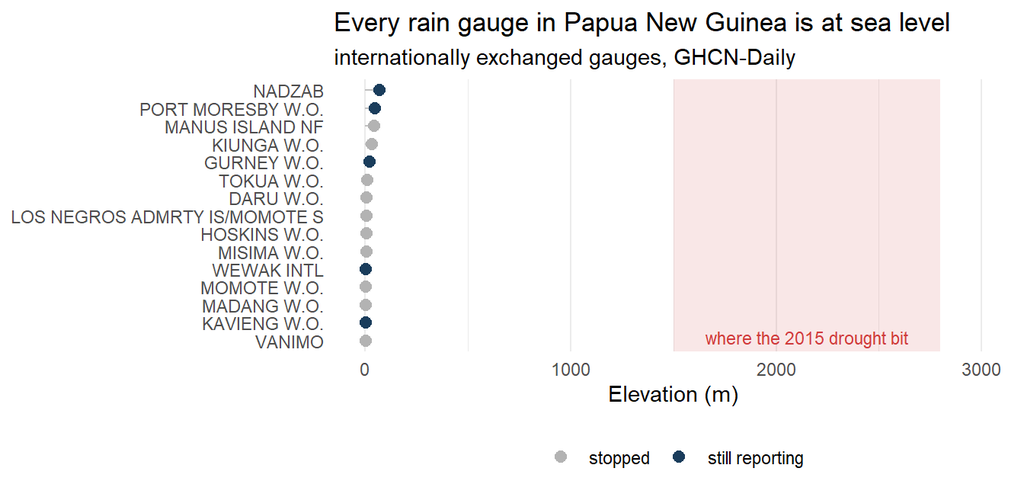

```r
ggplot(png_gauges, aes(elev, fct_reorder(name, elev))) +
  annotate("rect", xmin = 1500, xmax = 2800, ymin = -Inf, ymax = Inf,
           fill = "#d03b3b", alpha = .12) +
  annotate("text", x = 2150, y = 1.2, label = "where the 2015 drought bit",
           size = 3, colour = "#d03b3b") +
  geom_segment(aes(x = 0, xend = elev, yend = name),
               colour = "grey75", linewidth = .4) +
  geom_point(aes(colour = last >= ACTIVE_CUT), size = 2.4) +
  scale_x_continuous(limits = c(0, 3000)) +
  scale_y_discrete() +
  scale_colour_manual(values = c("TRUE" = "#1a3d5c", "FALSE" = "grey70"),
                      labels = c("TRUE" = "still reporting", "FALSE" = "stopped"),
                      name = NULL) +
  labs(title = "Every rain gauge in Papua New Guinea is at sea level",
       subtitle = "internationally exchanged gauges, GHCN-Daily",
       x = "Elevation (m)", y = NULL) +
  theme_minimal() +
  theme(legend.position = "bottom", panel.grid.major.y = element_blank())
```

The highland stations do exist. They are simply not switched on.

```r
png_land <- filter(land, country == "Papua New Guinea") %>%
  select(name, received, expected, status) %>%
  arrange(desc(received), name)

png_land
```

```
## # A tibble: 14 × 4
##    name              received expected status
##    <chr>                <dbl>    <dbl> <chr>
##  1 PORT MORESBY W.O.      209      248 green
##  2 KAVIENG W.O.            39      620 red
##  3 NADZAB W.O.             38       93 orange
##  4 TOKUA W.O.              31      403 red
##  5 DARU W.O.                0      434 black
##  6 GOROKA ATS               0      403 black
##  7 GURNEY W.O.              0      434 black
##  8 KIUNGA W.O.              0      341 black
##  9 MADANG W.O.              0      465 black
## 10 MISIMA W.O.              0      434 black
## 11 MOMOTE W.O.              0      620 black
## 12 Mendi North              0      248 black
## 13 VANIMO                   0      248 black
## 14 WEWAK W.O.               0      620 black
```

Papua New Guinea has 14 surface stations registered with WMO. Across July 2026 they returned 317 of 5,611 expected observations — 6% — and 10 of them sent nothing at all. Two of the silent ones are **Goroka** and **Mendi North**: Eastern and Southern Highlands, at altitude, in the provinces the drought hit hardest. Goroka returned 0 of 403 expected observations that month. Mendi North, 0 of 248.

## The upper-air layer has gone

```r
upper_hist <- igra %>%
  group_by(country) %>%
  summarise(sites_ever = n(), active = sum(last >= 2024),
            last_year = max(last), .groups = "drop")

lost  <- filter(upper_hist, country %in% pict, active == 0, sites_ever > 0)
never <- setdiff(pict, igra$country)

arrange(lost, desc(last_year)) %>% select(country, sites_ever, last_year)
```

```
## # A tibble: 6 × 3
##   country                  sites_ever last_year
##   <chr>                         <int>     <int>
## 1 Papua New Guinea                  8      2015
## 2 Nauru                             1      2013
## 3 Solomon Islands                   2      2011
## 4 Tonga                             2      1999
## 5 Northern Mariana Islands          1      1992
## 6 Samoa                             1      1989
```

```r
never
```

```
## [1] "Niue"              "Tokelau"           "Wallis and Futuna"
## [4] "Pitcairn"
```

Papua New Guinea’s last sounding was in **2015**. Not the year before the drought, or the year after. The year of it. Solomon Islands stopped in 2011, Nauru in 2013, Tonga in 1999, Samoa in 1989. Niue, Tokelau, Wallis and Futuna, and Pitcairn never had one.

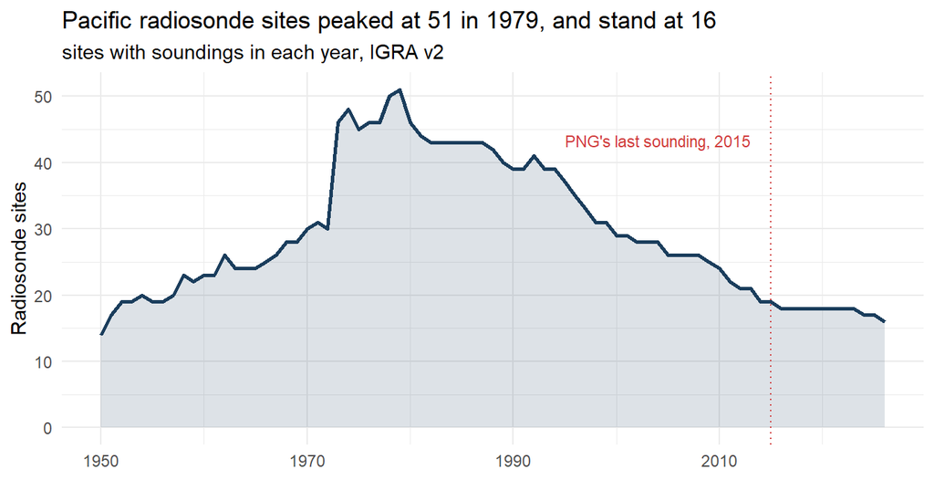

```r
pic_sondes <- filter(igra, country %in% pict)

active_by_year <- tibble(year = 1950:2026) %>%
  mutate(sites = map_int(year, ~ sum(pic_sondes$first <= .x & pic_sondes$last >= .x)))

peak      <- slice_max(active_by_year, sites, n = 1, with_ties = FALSE)
now_sites <- filter(active_by_year, year == 2026)$sites

ggplot(active_by_year, aes(year, sites)) +
  geom_area(fill = "#1a3d5c", alpha = .15) +
  geom_line(colour = "#1a3d5c", linewidth = 1) +
  geom_vline(xintercept = 2015, linetype = "dotted", colour = "#d03b3b") +
  annotate("text", x = 2013, y = peak$sites * .85,
           label = "PNG's last sounding, 2015",
           hjust = 1, size = 3, colour = "#d03b3b") +
  labs(title = paste0("Pacific radiosonde sites peaked at ", peak$sites,
                      " in ", peak$year, ", and stand at ", now_sites),
       subtitle = "sites with soundings in each year, IGRA v2",
       x = NULL, y = "Radiosonde sites") +
  theme_minimal()
```

This is the layer that dies first, and it dies quietly. Every launch consumes a balloon, gas and a sonde. Upper-air observation is not a thing you install; it is a thing you pay for twice a day, forever, with trained staff. So it is the first line item to go when a programme ends, and its ending produces no visible event. The forecast kept arriving — interpolated from whatever instrument was nearest and still working, still about right for the region and much less useful for any one valley — and a record that ran for decades stopped without anyone signing off on it.

# 6. Existing is not reporting, and who pays decides which

A station in the register is not a station sending data. WMO monitors both, and the difference between them is where the network quietly stopped.

```r
rates <- bind_rows(reporting_rate(land,  "Surface"),
                   reporting_rate(upper, "Upper air"))

rates %>%
  select(country, layer, registered, reporting, silent, received, expected, pct_obs) %>%
  arrange(layer, pct_obs)
```

```
## # A tibble: 39 × 8
##    country          layer  registered reporting silent received expected pct_obs
##    <chr>            <chr>       <int>     <int>  <int>    <dbl>    <dbl>   <dbl>
##  1 Nauru            Surfa…          2         0      2        0      992       0
##  2 Papua New Guinea Surfa…         14         1     10      317     5611       6
##  3 Samoa            Surfa…         11         2      9      493     6696       7
##  4 Marshall Islands Surfa…          7         0      6      229     2418       9
##  5 Micronesia       Surfa…         15         0      6      789     5239      15
##  6 Palau            Surfa…          2         0      1      123      837      15
##  7 Niue             Surfa…          1         0      0      101      248      41
##  8 American Samoa   Surfa…          1         0      0      121      248      49
##  9 Tuvalu           Surfa…          4         1      0      513      961      53
## 10 Kiribati         Surfa…          7         3      1      943     1457      65
## # ℹ 29 more rows
```

Papua New Guinea has 2 radiosonde stations registered with WMO and received **0 of 124** expected soundings in July 2026. Solomon Islands and Tuvalu are also registered for upper-air observation, and also sent nothing. The obligation is on the books. The balloons are not going up.

The two layers also come apart *inside the same country*, and that is the tell.

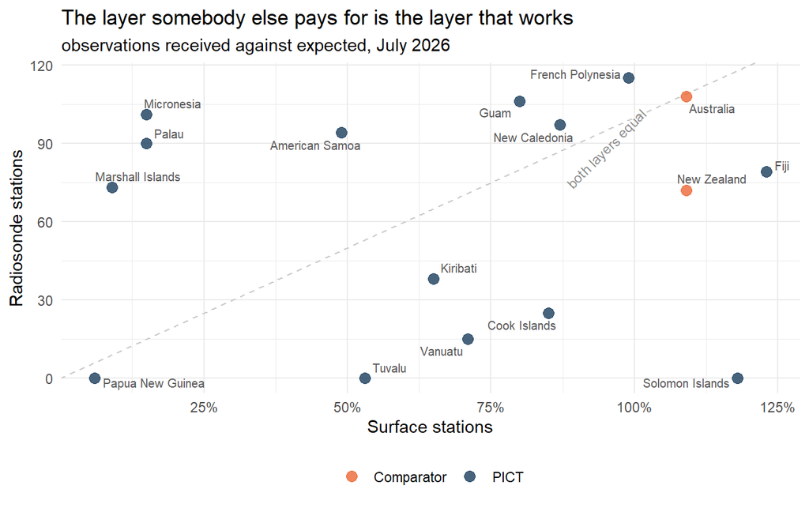

```r
paired <- rates %>%
  filter(!is.na(pct_obs)) %>%
  select(country, grp, layer, pct_obs) %>%
  pivot_wider(names_from = layer, values_from = pct_obs) %>%
  filter(!is.na(Surface), !is.na(`Upper air`))

ggplot(paired, aes(Surface, `Upper air`)) +
  geom_abline(slope = 1, intercept = 0, colour = "grey80", linetype = "dashed") +
  annotate("text", x = 95, y = 88, label = "both layers equal",
           angle = 45, size = 3, colour = "grey55") +
  geom_point(aes(colour = grp), size = 3, alpha = .8) +
  geom_text_repel(aes(label = country), size = 2.7, colour = "grey35",
                  seed = 1, max.overlaps = 20) +
  scale_colour_manual(values = c(PICT = "#1a3d5c", Comparator = "#eb6834"),
                      name = NULL) +
  scale_x_continuous(labels = \(x) paste0(x, "%")) +
  labs(title = "The layer somebody else pays for is the layer that works",
       subtitle = "observations received against expected, July 2026",
       x = "Surface stations", y = "Radiosonde stations") +
  theme_minimal() +
  theme(legend.position = "bottom")
```

Micronesia returned 101% of its expected soundings and 15% of its expected surface observations. Palau, 90% against 15%. The Marshall Islands, 73% against 9%.

These are the same countries, the same staff, the same islands. What differs is that the radiosonde programme in the freely associated states is run and funded through the United States National Weather Service, while the surface network is a national responsibility. Where an outside programme carries the recurring cost, the observations arrive. Where it does not, they do not — and the pattern reverses cleanly for Papua New Guinea, which is on its own for both.

That is not a comment on anyone’s competence. It is a statement about which line items have a funder, and it says where money would actually change something.

It is also what makes the gap so easy to miss. Every silent station is still counted. They appear in the register, in the network totals, and in any assessment built on how many stations a country has. On paper the region is better observed than it was thirty years ago.

# 7. Close

The same administrative logic decides what *is* watched. Sea level is measured carefully in places with no working weather station at all — not because anyone judged one threat to matter more, but because tide gauges and rain gauges are different instruments, installed by different programmes, on different funding cycles.

```r
latest  <- stations %>% filter(year == max(year)) %>% select(country, n = value)
watched <- latest %>%
  mutate(sea_level = country %in% unique(sea_lvl$country))

sum(watched$sea_level)
```

```
## [1] 17
```

```r
filter(watched, n == 0, sea_level)
```

```
##   country n sea_level
## 1    Niue 0      TRUE
## 2   Nauru 0      TRUE
```

That is worth saying plainly, because it makes this a fixable administrative fact rather than a natural feature of small islands.

The Pacific can describe its rainfall after the fact, thinly and in the wrong places. It cannot see it coming. The layer of the atmosphere that would show it arriving has been switched off across most of the region, one station at a time, and much of what remains on the ground is registered, counted, and silent.

*You cannot get ready for a change you cannot watch arriving. How ready are we for the next El Niño?*

[^1]: R.M. Bourke, Bryant Allen and Michael Lowe, *Estimated impact of drought and frost on food supply in rural PNG in 2015*, Development Policy Centre Policy Brief 11, Australian National University, January 2016, pp. 1–2. “Since April 2015, much of rural Papua New Guinea (PNG) has been severely impacted by a severe drought and, at a number of very high altitude locations above 2200 m altitude, by repeated frosts.” Frost temperatures of −2 °C were recorded between 5 and 7 am at Tambul High Altitude Agricultural Research Station between mid-July and mid-August 2015 (Kud Sitango, NARI Tambul, pers. comm.). Sweet potato takes 8–12 months to mature above 2,200 m (p. 5).
[^2]: Bourke, Allen and Lowe, op. cit., pp. 2, 4–5 and Tables 2–3. 27 of 271 rural LLGAs at rating 4 or 5; a maximum of 770,000 people, which the authors describe as “an upper limit” with the number very short of food “likely to be considerably less”; 53% at very high altitude and 35% in the central highlands or highlands fringe; food supply information obtained for 141 LLG areas and extrapolated to the remaining 130; “the only national assessment of the food supply situation for all PNG at the LLGA level”.
[^3]: DFAT Office of Development Effectiveness, *Evaluation of Australia’s response to the PNG El Niño drought and frosts 2015–17*: “The researchers recommended field checking to clarify actual numbers and set priorities; but this was not undertaken.” Verified against the document.
[^4]: DFAT evaluation, op. cit.: “It is likely that there was some increase is [sic] all-causes mortality due to the 2015 El Niño… But such an increase is impossible to quantify.” Verified against the document.
[^5]: DFAT evaluation, op. cit.: “By early April 2015 climate scientists, including from the Australian Bureau of Meteorology, were reporting on the likelihood of a severe El Niño event, moving from the eastern Pacific westwards.” Verified against the document.